# Zombie Homework Problem Week 4

Brandon Güell

9/26/2017

```r
library(curl)
f <- f <- curl("https://raw.githubusercontent.com/fuzzyatelin/fuzzyatelin.github.io/master/AN597_Fall17/zombies.csv")
d <- read.csv(f, header = TRUE, sep = ",", stringsAsFactors = FALSE)
head(d)
```

```
##   id first_name last_name gender   height   weight zombies_killed
## 1  1      Sarah    Little Female 62.88951 132.0872              2
## 2  2       Mark    Duncan   Male 67.80277 146.3753              5
## 3  3    Brandon     Perez   Male 72.12908 152.9370              1
## 4  4      Roger   Coleman   Male 66.78484 129.7418              5
## 5  5      Tammy    Powell Female 64.71832 132.4265              4
## 6  6    Anthony     Green   Male 71.24326 152.5246              1
##   years_of_education                           major      age
## 1                  1                medicine/nursing 17.64275
## 2                  3 criminal justice administration 22.58951
## 3                  1                       education 21.91276
## 4                  6                  energy studies 18.19058
## 5                  3                       logistics 21.10399
## 6                  4                  energy studies 21.48355
```

# 1

Calculate the population mean and standard deviation for each quantitative random variable (height, weight, age, number of zombies killed, and years of education). NOTE: You will not want to use the built in var() and sd() commands as these are for samples.

so we know this is a population, not a sample. I think the means are the same for a pop and sample so lets start with that

```r
library(dplyr)
mean_of_variables<-d %>%
summarise(mean(height), mean(weight), mean(age), mean(zombies_killed), mean(years_of_education))
mean_of_variables
```

```
##   mean(height) mean(weight) mean(age) mean(zombies_killed)
## 1      67.6301     143.9075  20.04696                2.992
##   mean(years_of_education)
## 1                    2.996
```

```r
#standard deviation for pop== sqrt(sum((x - mean(x))^2)/length(x))
#lets create a function so that we dont have to type it out for each one! lol maybe!
#awesome i found it in module 7!!! here it is, first the variance then the sd of a pop
pop_v <- function(x) {sum((x - mean(x))^2)/(length(x))}
#create vector of variances
hvar=pop_v(d$height)
wvar=pop_v(d$weight)
avar=pop_v(d$age)
zkvar=pop_v(d$zombies_killed)
yoevar=pop_v(d$years_of_education)
#Just realized after that i dont need these variables LOL... o well

#now the function for sd of a pop
pop_sd <- function(x) {
  sqrt(pop_v(x))}
#then lets run that function on our newly made varaibles
sd_of_variables=c(pop_sd(d$height),pop_sd(d$weight),pop_sd(d$age),pop_sd(d$zombies_killed),pop_sd(d$years_of_education))
sd_of_variables
```

```
## [1]  4.307970 18.391857  2.963583  1.747551  1.675704
```

```r
#okay so finished products are here:

mean_of_variables
```

```
##   mean(height) mean(weight) mean(age) mean(zombies_killed)
## 1      67.6301     143.9075  20.04696                2.992
##   mean(years_of_education)
## 1                    2.996
```

```r
sd_of_variables
```

```
## [1]  4.307970 18.391857  2.963583  1.747551  1.675704
```

# 2

now to plot stuff on ggplot: Use {ggplot} and make boxplots of each of these variables by gender.

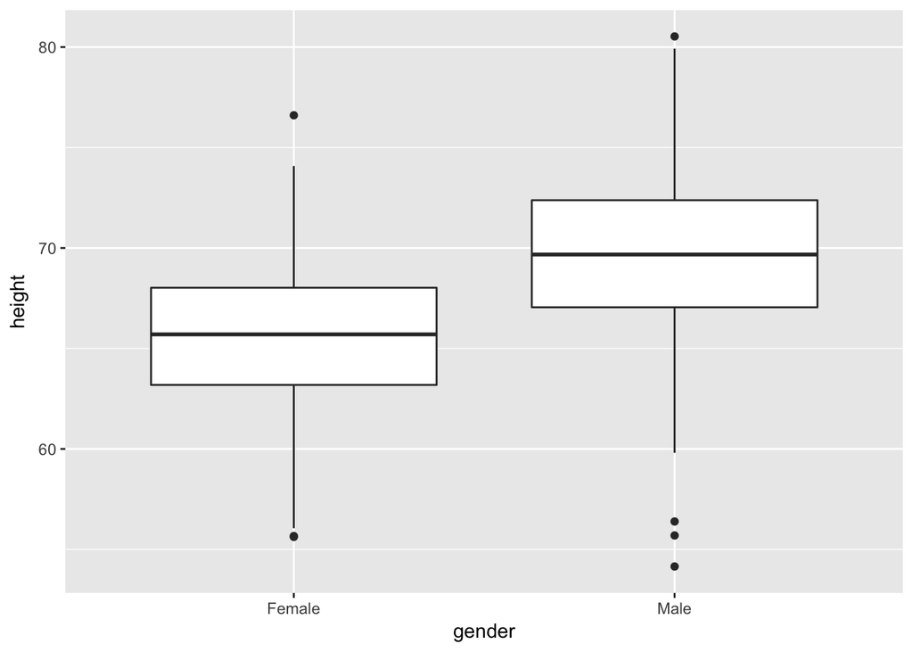

```r
library(ggplot2)

plot_height= ggplot(data=d, aes(x=gender, y=height)) + geom_boxplot()
plot_height
```

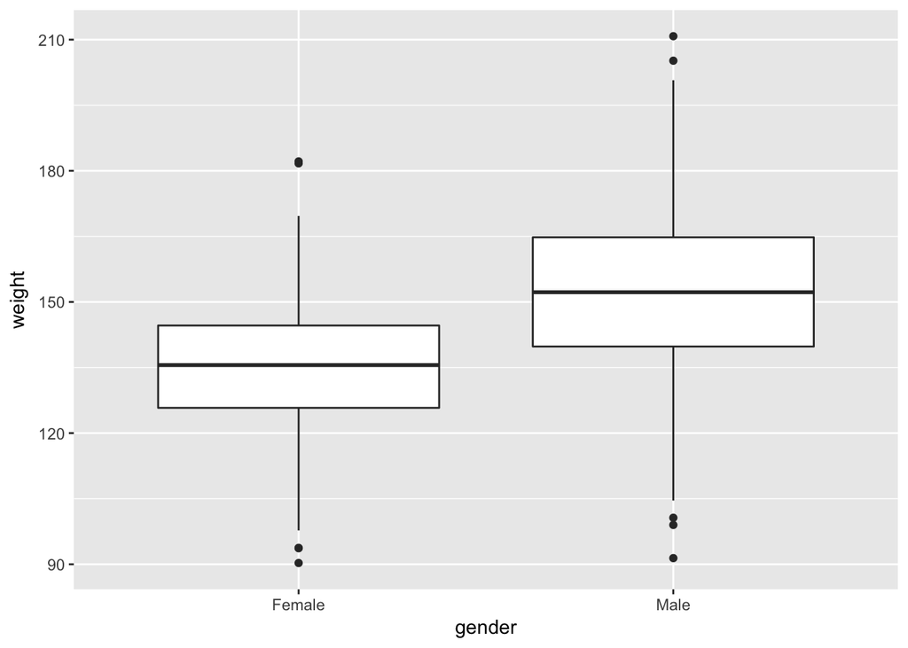

```r
plot_weight= ggplot(data=d, aes(x=gender, y=weight)) + geom_boxplot()
plot_weight
```

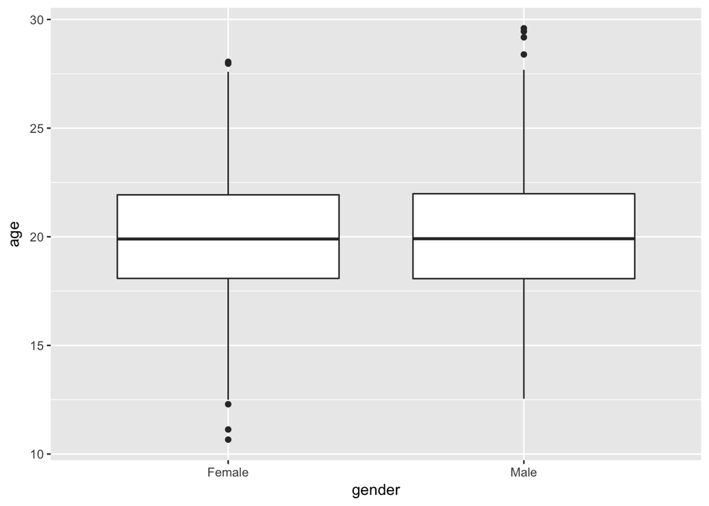

```r
plot_age= ggplot(data=d, aes(x=gender, y=age)) + geom_boxplot()
plot_age
```

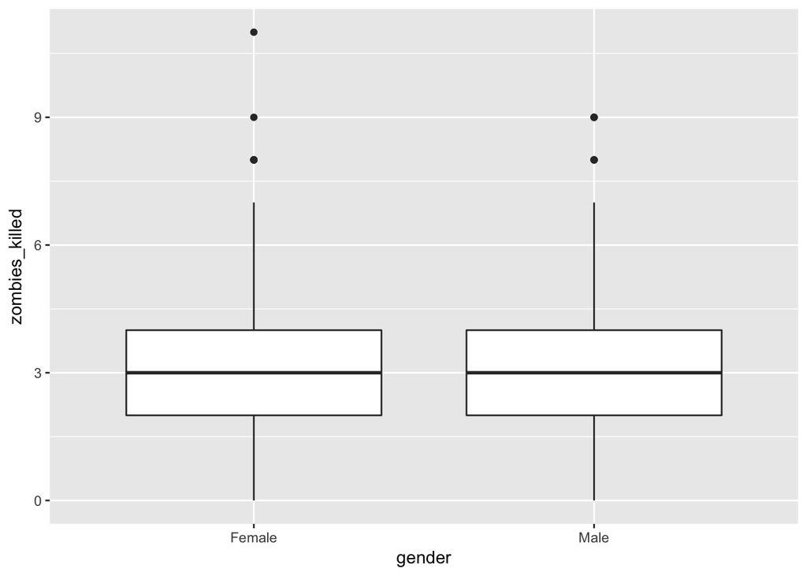

```r
plot_zk= ggplot(data=d, aes(x=gender, y=zombies_killed)) + geom_boxplot()
plot_zk
```

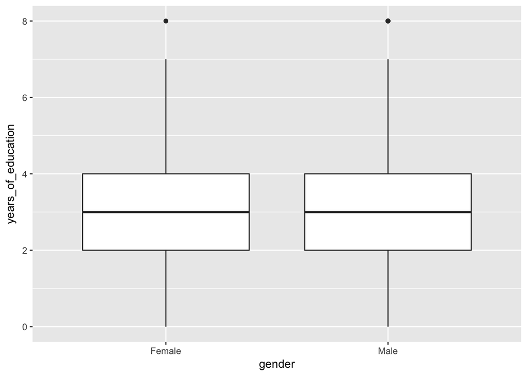

```r
plot_yoe= ggplot(data=d, aes(x=gender, y=years_of_education)) + geom_boxplot()
plot_yoe
```

#3 Scatterplots:Use {ggplot} and make scatterplots of height and weight in relation to age. Do these variables seem to be related? In what way?

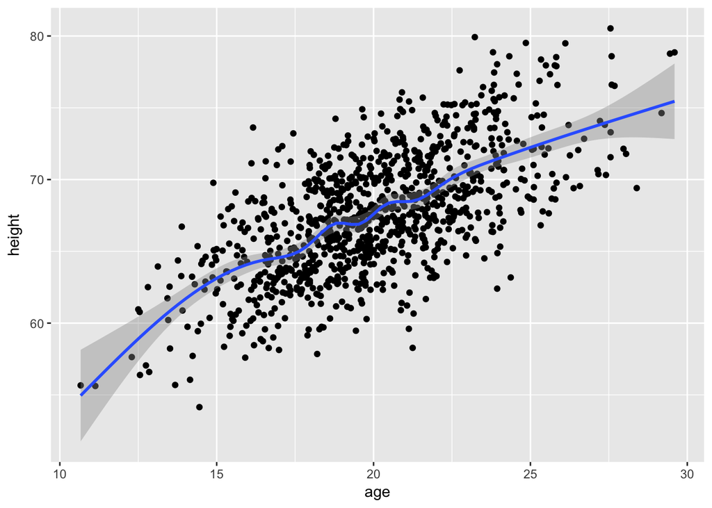

```r
g= ggplot(data=d, aes(x=age, y=height)) + geom_point() + geom_smooth()
g
```

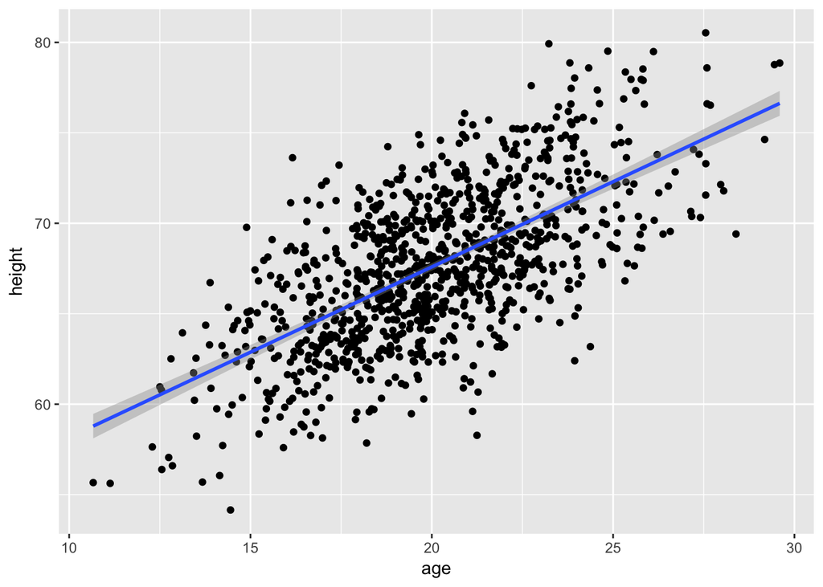

```r
#height seems to increase with age: positive correlation... you can see it nicely here also:
g= ggplot(data=d, aes(x=age, y=height)) + geom_point() + geom_smooth(method = "lm")
g
```

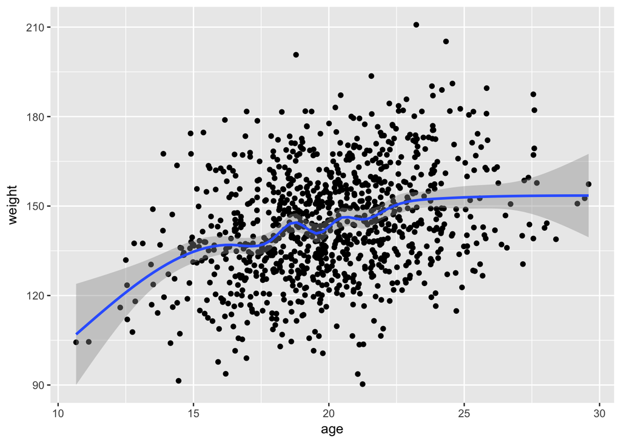

```r
g= ggplot(data=d, aes(x=age, y=weight)) + geom_point() + geom_smooth()
g
```

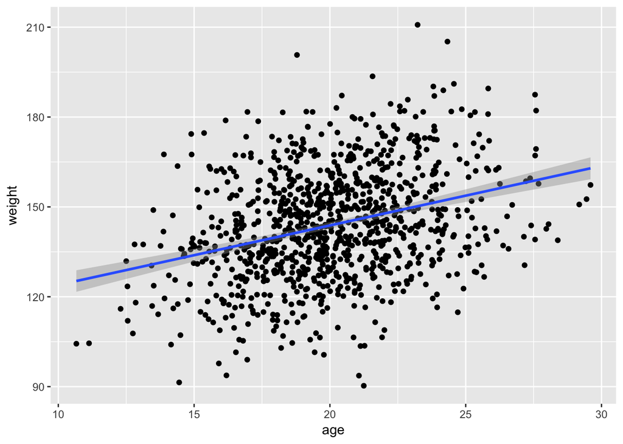

```r
#weight seems to be less strongly correlated with age, but still a positive correlation
g= ggplot(data=d, aes(x=age, y=weight)) + geom_point() + geom_smooth(method = "lm")
g
```

```r
#so they are related because as age increases, they both increase?... makes logical sense also
```

# 4

Using histograms and Q-Q plots, check whether the quantitative variables seem to be drawn from a normal distribution. Which seem to be and which do not (hint: not all are drawn from the normal distribution)? For those that are not, can you determine what common distribution they are drawn from?

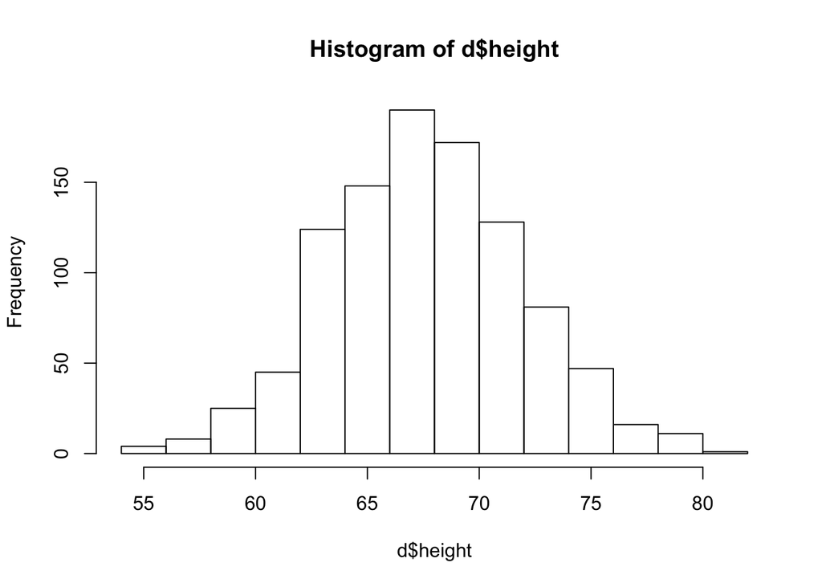

```r
#lets start with height...
hist(d$height) #seems super normal to me... lets check with Q-Q
```

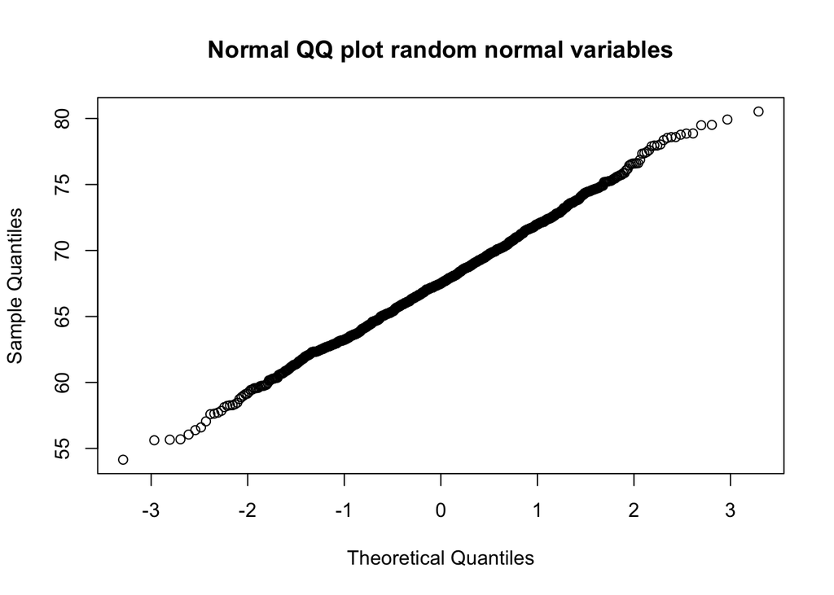

```r
qqnorm(d$height, main = "Normal QQ plot random normal variables") #yup seems normal
```

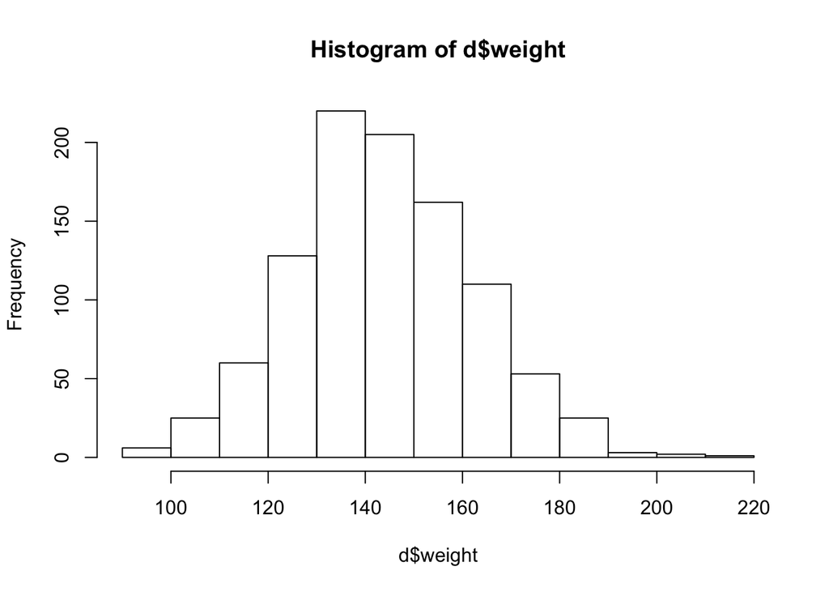

```r
#weight
hist(d$weight) #hmm less perfectly normal than before but i think it counts! lets check!
```

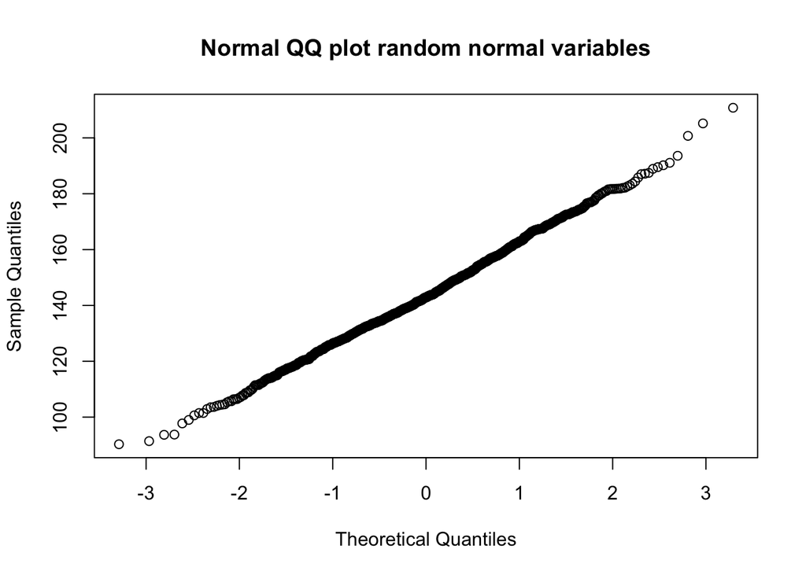

```r
qqnorm(d$weight, main = "Normal QQ plot random normal variables") #yup seems normal
```

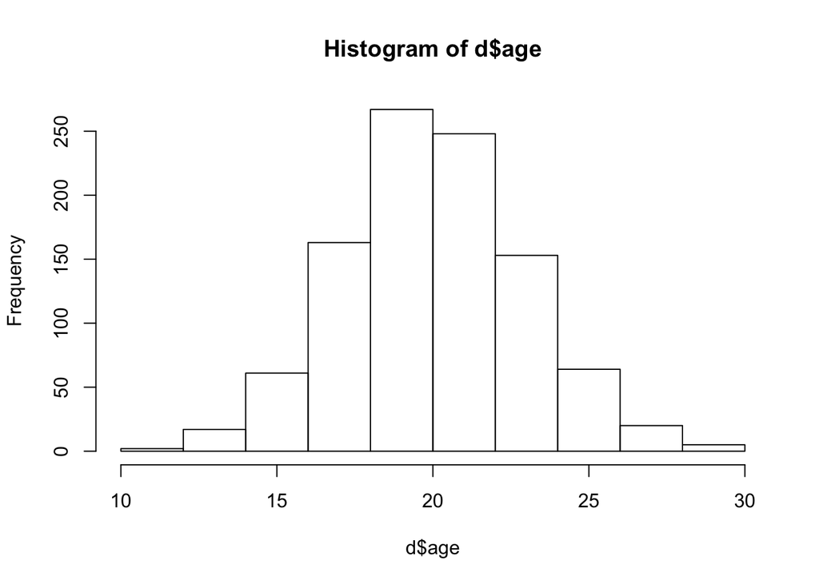

```r
#age
hist(d$age) #looks normal
```

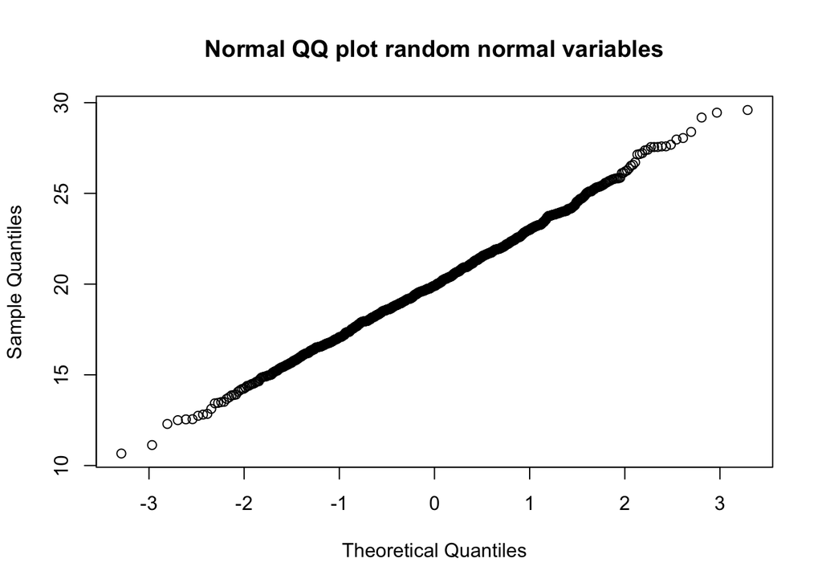

```r
qqnorm(d$age, main = "Normal QQ plot random normal variables") #yup seems normal again
```

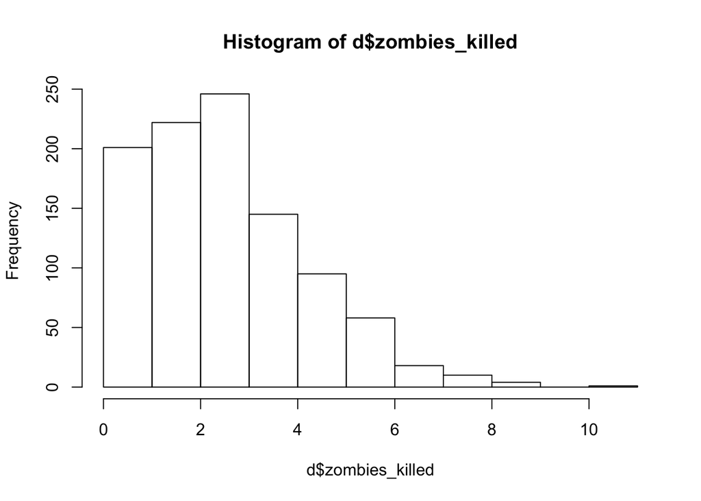

```r
#zombies killed
hist(d$zombies_killed) #definitely NOT normal... I'd guess Poisson dist. or geometric?
```

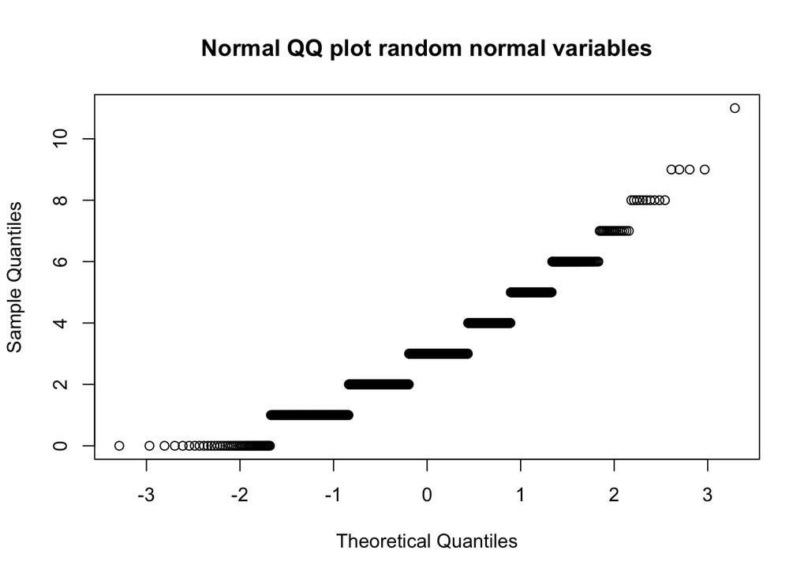

```r
qqnorm(d$zombies_killed, main = "Normal QQ plot random normal variables") #definitely NOT normal
```

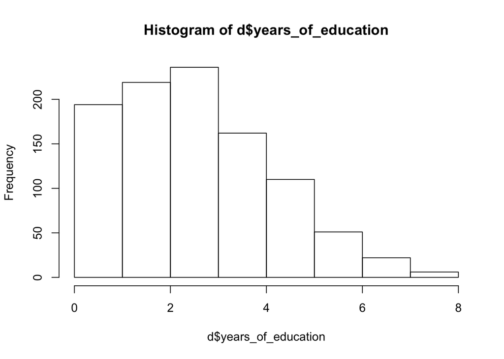

```r
#years of education
hist(d$years_of_education) #again definitely NOT normal...  Poisson dist. or geometric? again
```

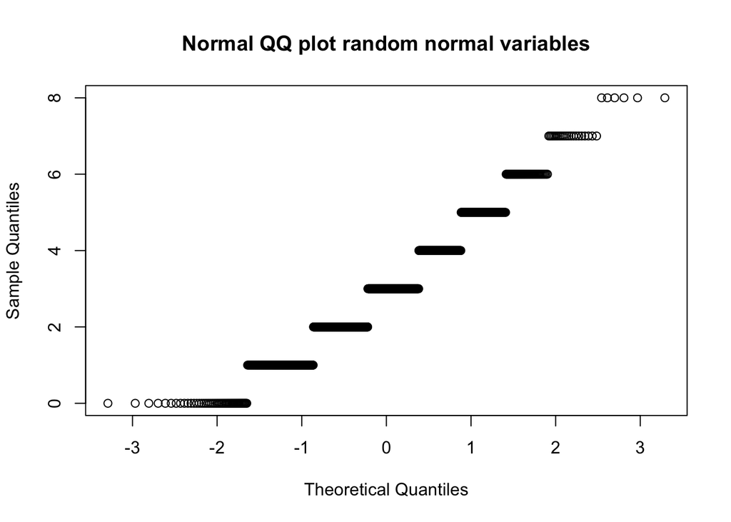

```r
qqnorm(d$years_of_education, main = "Normal QQ plot random normal variables") #definitely NOT normal
```

# 5

Now use the sample() function to sample ONE subset of 30 zombie survivors (without replacement) from this population and calculate the mean and sample standard deviation for each variable. Also estimate the standard error for each variable and construct the 95% confidence interval for each mean. Note that for the variables that are not drawn from the normal distribution, you will need to base your estimate of the CIs on some different distribution

```r
#had to look this up... dplyr has a nice function lets use it
library(dplyr)
sample1=sample_n(d, size=30, replace = FALSE) # BOOYAA worked! oh shit its not the sample() function though... lol o well this was easier?!
sample1
```

```
##      id  first_name last_name gender   height   weight zombies_killed
## 933 933         Amy    Willis Female 67.89424 124.2984              5
## 729 729 Christopher Henderson   Male 72.78263 149.9674              2
## 491 491     Shirley      Sims Female 62.33724 119.9920              3
## 416 416        Mark   Simpson   Male 68.40776 171.1671              2
## 51   51      George    Pierce   Male 67.97952 151.0887              6
## 648 648       Jerry     Young   Male 65.87925 141.1870              1
## 254 254    Benjamin    Rogers   Male 72.42676 169.0869              0
## 101 101      Gerald   Alvarez   Male 72.30678 164.5499              3
## 172 172     Theresa    Martin Female 69.38269 140.2724              4
## 647 647       Wanda    Rogers Female 72.07851 148.8549              3
## 464 464        Lois    Brooks Female 62.73514 114.0732              3
## 868 868     Gregory    Harris   Male 74.21998 157.3538              3
## 960 960    Clarence     Gomez   Male 78.86801 190.2005              3
## 96   96      Johnny      Cook   Male 69.05417 155.8221              1
```

[output cut: 47 more lines]

```r
mean_of_sample_variables<-sample1 %>%
summarise(mean(height), mean(weight), mean(age), mean(zombies_killed), mean(years_of_education))
mean_of_sample_variables
```

```
##   mean(height) mean(weight) mean(age) mean(zombies_killed)
## 1     67.95958     143.0463  20.15367                  2.7
##   mean(years_of_education)
## 1                        3
```

```r
#now we can do the sd() function. YAY that is easier... here it is

sd_of_sample_variables<-sample1 %>%
summarise(sd(height), sd(weight), sd(age), sd(zombies_killed), sd(years_of_education))
sd_of_sample_variables
```

```
##   sd(height) sd(weight)  sd(age) sd(zombies_killed) sd(years_of_education)
## 1   5.057583   22.04521 2.795675           1.600646               1.893728
```

```r
#now standard error... i remember seeing a package with se() function.. that is easy lol im going to find it/look it up
library(sciplot)
?se
se_of_sample_variables<-sample1 %>%
summarise(se(height), se(weight), se(age), se(zombies_killed), se(years_of_education))
se_of_sample_variables
```

```
##   se(height) se(weight)  se(age) se(zombies_killed) se(years_of_education)
## 1  0.9233842   4.024886 0.510418          0.2922367              0.3457459
```

```r
#nice! I assume this works for this sample becasue i called it from sample1 which is a sample already???

#okay now CI of each.. let me find that code!
#so here is code for a generic formula:
normalCI = function(x, CIlevel = 0.95) {
    upper = mean(x) + qnorm(1 - (1 - CIlevel)/2) * sqrt(var(x)/length(x))
    lower = mean(x) + qnorm((1 - CIlevel)/2) * sqrt(var(x)/length(x))
    ci <- c(lower, upper)
    return(ci)
}
hCI=normalCI(sample1$height, 0.95)
wCI=normalCI(sample1$weight, 0.95)
aCI=normalCI(sample1$age, 0.95) #sweet!

hCI
```

```
## [1] 66.14978 69.76938
```

```r
wCI
```

```
## [1] 135.1577 150.9350
```

```r
aCI #cool...
```

```
## [1] 19.15327 21.15408
```

```r
normalCI(sample1$zombies_killed, 0.95) # this DOES NOT WORK... not normal...
```

```
## [1] 2.127227 3.272773
```

```r
normalCI(sample1$years_of_education, 0.95)# this DOES NOT WORK... not normal...
```

```
## [1] 2.32235 3.67765
```

```r
#so for those two im guessign we have to bootstrap. here goes nothing, or everything i guess
#An alternative way to calculate a confidence interval is by simulation, which does not presume the underlying distribution from which the random variable is drawn.....== from module so YES lets use bootstrapping

set <- NULL  # sets up a dummy variable to hold our 10000 simulations
n <- 15
for (i in 1:10000) {
    set[i] <- mean(sample(sample1$zombies_killed, n, replace = TRUE))
}
zkCI=quantile(set, c(0.025, 0.975))


#and again for years of education
set <- NULL
n <- 15
for (i in 1:10000) {
    set[i] <- mean(sample(sample1$years_of_education, n, replace = TRUE))
}
yoeCI=quantile(set, c(0.025, 0.975))

#so here they are:
zkCI
```

```
##     2.5%    97.5%
## 1.933333 3.533333
```

```r
yoeCI
```

```
##     2.5%    97.5%
## 2.066667 3.933333
```

# 6

Now draw 99 more random samples of 30 zombie survivors out and calculate the mean for each of the these samples. Together with the first sample you drew out, you now have a set of 100 means for each variable (each based on 30 observations), which constitutes a sampling distribution for each variable. What are the means and standard deviations of this distribution for each variable? How do the standard deviations compare to the standard errors estimated in 5? What do these sampling distributions look like? Are they normally distributed? What about for those variables that you concluded were not originally drawn from a normal distribution?

# weight

```r
set <- NULL  # sets up a dummy variable to hold our 10000 simulations
n <- 30
for (i in 1:99) {
    set[i] <- mean(sample(d$weight, n, replace = FALSE))
    }
set
```

```
##  [1] 149.8934 145.1378 145.4774 144.7563 148.4231 146.8731 138.6438
##  [8] 143.5294 139.1387 140.0759 148.7809 141.3322 145.1806 140.5348
## [15] 143.6699 145.0679 141.9163 146.5305 144.4926 143.3177 145.9834
## [22] 136.6020 141.2436 145.9827 146.1988 147.3693 144.9492 136.8091
## [29] 145.3046 148.2431 145.7232 144.8040 143.9455 148.5116 149.1484
## [36] 139.6384 143.8217 148.5553 151.5373 142.0479 143.7307 150.3916
## [43] 147.7050 143.4138 141.6525 139.4068 144.1358 151.2725 146.8906
## [50] 145.9748 141.3897 142.1893 145.7172 144.7263 143.7769 145.6422
## [57] 143.9707 143.0125 147.1138 140.1031 142.9021 141.7216 144.1431
## [64] 140.4181 147.8654 150.0332 143.8788 141.1801 140.4075 148.4921
## [71] 146.0534 147.7130 147.7092 145.4188 140.5235 148.9633 142.6187
## [78] 154.5024 145.3423 138.6932 137.7080 139.1460 139.1628 145.4404
## [85] 150.9126 141.5764 149.1774 140.9760 138.9949 147.5502 143.8008
## [92] 142.0280 136.9143 147.4725 136.6689 146.1036 148.8013 140.8925
## [99] 146.5840
```

```r
mean_of_sample_variables2w=mean(c(set,mean_of_sample_variables$`mean(weight)`))
mean_of_sample_variables2w
```

```
## [1] 144.3294
```

```r
sd_of_sample_variables2w=sd(c(set, sd_of_sample_variables$`sd(weight)`))
sd_of_sample_variables2w
```

```
## [1] 12.78751
```

```r
#distributions of all 100
set
```

```
##  [1] 149.8934 145.1378 145.4774 144.7563 148.4231 146.8731 138.6438
##  [8] 143.5294 139.1387 140.0759 148.7809 141.3322 145.1806 140.5348
## [15] 143.6699 145.0679 141.9163 146.5305 144.4926 143.3177 145.9834
## [22] 136.6020 141.2436 145.9827 146.1988 147.3693 144.9492 136.8091
## [29] 145.3046 148.2431 145.7232 144.8040 143.9455 148.5116 149.1484
## [36] 139.6384 143.8217 148.5553 151.5373 142.0479 143.7307 150.3916
## [43] 147.7050 143.4138 141.6525 139.4068 144.1358 151.2725 146.8906
## [50] 145.9748 141.3897 142.1893 145.7172 144.7263 143.7769 145.6422
## [57] 143.9707 143.0125 147.1138 140.1031 142.9021 141.7216 144.1431
## [64] 140.4181 147.8654 150.0332 143.8788 141.1801 140.4075 148.4921
## [71] 146.0534 147.7130 147.7092 145.4188 140.5235 148.9633 142.6187
## [78] 154.5024 145.3423 138.6932 137.7080 139.1460 139.1628 145.4404
## [85] 150.9126 141.5764 149.1774 140.9760 138.9949 147.5502 143.8008
## [92] 142.0280 136.9143 147.4725 136.6689 146.1036 148.8013 140.8925
## [99] 146.5840
```

```r
h=c(set,mean_of_sample_variables$`mean(weight)`)
h
```

```
##   [1] 149.8934 145.1378 145.4774 144.7563 148.4231 146.8731 138.6438
##   [8] 143.5294 139.1387 140.0759 148.7809 141.3322 145.1806 140.5348
##  [15] 143.6699 145.0679 141.9163 146.5305 144.4926 143.3177 145.9834
##  [22] 136.6020 141.2436 145.9827 146.1988 147.3693 144.9492 136.8091
##  [29] 145.3046 148.2431 145.7232 144.8040 143.9455 148.5116 149.1484
##  [36] 139.6384 143.8217 148.5553 151.5373 142.0479 143.7307 150.3916
##  [43] 147.7050 143.4138 141.6525 139.4068 144.1358 151.2725 146.8906
##  [50] 145.9748 141.3897 142.1893 145.7172 144.7263 143.7769 145.6422
##  [57] 143.9707 143.0125 147.1138 140.1031 142.9021 141.7216 144.1431
##  [64] 140.4181 147.8654 150.0332 143.8788 141.1801 140.4075 148.4921
##  [71] 146.0534 147.7130 147.7092 145.4188 140.5235 148.9633 142.6187
##  [78] 154.5024 145.3423 138.6932 137.7080 139.1460 139.1628 145.4404
##  [85] 150.9126 141.5764 149.1774 140.9760 138.9949 147.5502 143.8008
##  [92] 142.0280 136.9143 147.4725 136.6689 146.1036 148.8013 140.8925
##  [99] 146.5840 143.0463
```

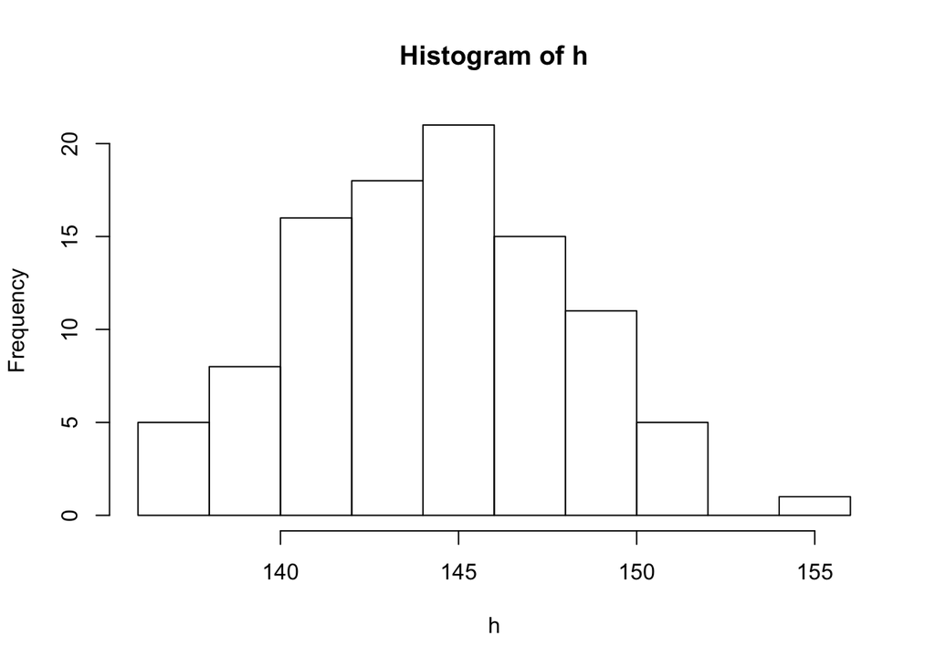

```r
hist(h) #seems super normal to me... lets check with Q-Q
```

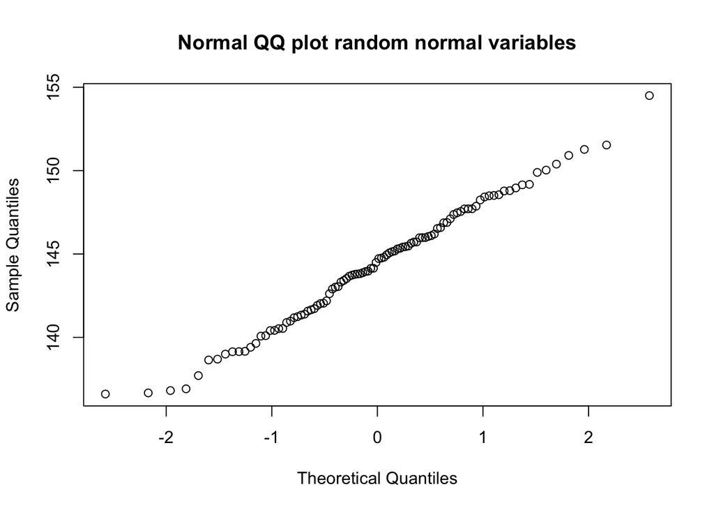

```r
qqnorm(h, main = "Normal QQ plot random normal variables") #yup seems normal
```

# height

```r
set <- NULL  # sets up a dummy variable to hold our 10000 simulations
n <- 30
for (i in 1:99) {
    set[i] <- mean(sample(d$height, n, replace = FALSE))
    }
set
```

```
##  [1] 67.52726 67.94341 68.18515 67.75088 68.30591 67.09002 66.73329
##  [8] 67.84902 68.59315 66.99052 67.58265 68.10665 66.62564 66.36067
## [15] 67.79347 68.23868 67.85633 67.69030 67.87421 67.53745 65.40603
## [22] 67.77712 67.16272 68.03579 67.59575 68.92207 67.73378 67.25597
## [29] 66.98222 67.98747 66.33599 67.49436 68.06540 67.41626 66.89287
## [36] 65.95467 68.07936 68.15702 67.51773 66.76937 66.67202 68.18116
## [43] 68.72948 68.31887 68.21202 67.06717 67.67057 66.53286 67.24272
## [50] 67.70586 68.78198 68.46007 68.36291 66.48437 66.23141 67.42996
## [57] 67.63687 67.99359 67.54846 67.68043 66.82666 68.97518 66.85348
## [64] 67.64385 67.61279 67.96142 67.71457 67.94166 68.82788 66.67368
## [71] 67.53603 69.20162 67.79763 67.53876 69.29920 69.05028 68.76636
## [78] 67.70530 67.58827 66.78378 66.62853 68.13910 66.02125 66.91119
## [85] 68.36397 68.47709 66.54384 68.13428 68.07546 67.52959 68.39686
## [92] 65.93613 67.62899 67.99649 67.77381 67.12883 67.31461 68.27667
## [99] 66.66156
```

```r
mean_of_sample_variables2h=mean(c(set,mean_of_sample_variables$`mean(height)`))
mean_of_sample_variables2h
```

```
## [1] 67.61316
```

```r
sd_of_sample_variables2h=sd(c(set, sd_of_sample_variables$`sd(height)`))
sd_of_sample_variables2h
```

```
## [1] 6.302979
```

```r
#distributions of all 100
set
```

```
##  [1] 67.52726 67.94341 68.18515 67.75088 68.30591 67.09002 66.73329
##  [8] 67.84902 68.59315 66.99052 67.58265 68.10665 66.62564 66.36067
## [15] 67.79347 68.23868 67.85633 67.69030 67.87421 67.53745 65.40603
## [22] 67.77712 67.16272 68.03579 67.59575 68.92207 67.73378 67.25597
## [29] 66.98222 67.98747 66.33599 67.49436 68.06540 67.41626 66.89287
## [36] 65.95467 68.07936 68.15702 67.51773 66.76937 66.67202 68.18116
## [43] 68.72948 68.31887 68.21202 67.06717 67.67057 66.53286 67.24272
## [50] 67.70586 68.78198 68.46007 68.36291 66.48437 66.23141 67.42996
## [57] 67.63687 67.99359 67.54846 67.68043 66.82666 68.97518 66.85348
## [64] 67.64385 67.61279 67.96142 67.71457 67.94166 68.82788 66.67368
## [71] 67.53603 69.20162 67.79763 67.53876 69.29920 69.05028 68.76636
## [78] 67.70530 67.58827 66.78378 66.62853 68.13910 66.02125 66.91119
## [85] 68.36397 68.47709 66.54384 68.13428 68.07546 67.52959 68.39686
## [92] 65.93613 67.62899 67.99649 67.77381 67.12883 67.31461 68.27667
## [99] 66.66156
```

```r
h=c(set,mean_of_sample_variables$`mean(height)`)
h
```

```
##   [1] 67.52726 67.94341 68.18515 67.75088 68.30591 67.09002 66.73329
##   [8] 67.84902 68.59315 66.99052 67.58265 68.10665 66.62564 66.36067
##  [15] 67.79347 68.23868 67.85633 67.69030 67.87421 67.53745 65.40603
##  [22] 67.77712 67.16272 68.03579 67.59575 68.92207 67.73378 67.25597
##  [29] 66.98222 67.98747 66.33599 67.49436 68.06540 67.41626 66.89287
##  [36] 65.95467 68.07936 68.15702 67.51773 66.76937 66.67202 68.18116
##  [43] 68.72948 68.31887 68.21202 67.06717 67.67057 66.53286 67.24272
##  [50] 67.70586 68.78198 68.46007 68.36291 66.48437 66.23141 67.42996
##  [57] 67.63687 67.99359 67.54846 67.68043 66.82666 68.97518 66.85348
##  [64] 67.64385 67.61279 67.96142 67.71457 67.94166 68.82788 66.67368
##  [71] 67.53603 69.20162 67.79763 67.53876 69.29920 69.05028 68.76636
##  [78] 67.70530 67.58827 66.78378 66.62853 68.13910 66.02125 66.91119
##  [85] 68.36397 68.47709 66.54384 68.13428 68.07546 67.52959 68.39686
##  [92] 65.93613 67.62899 67.99649 67.77381 67.12883 67.31461 68.27667
##  [99] 66.66156 67.95958
```

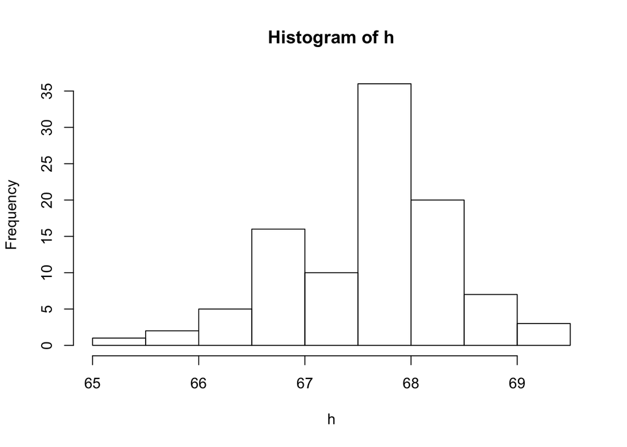

```r
hist(h) #seems super normal to me... lets check with Q-Q
```

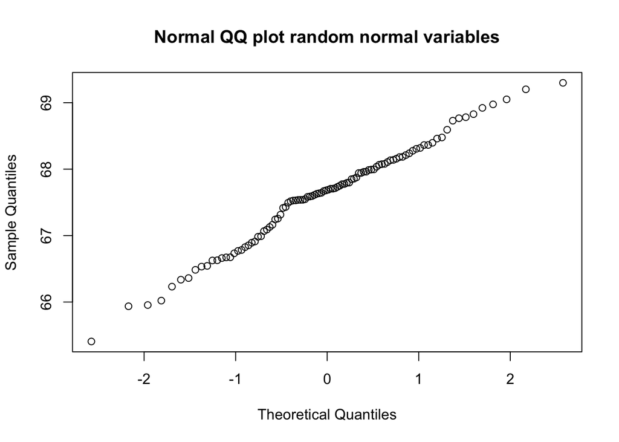

```r
qqnorm(h, main = "Normal QQ plot random normal variables") #yup seems normal
```

# age

```r
set <- NULL  # sets up a dummy variable to hold our 10000 simulations
n <- 30
for (i in 1:99) {
    set[i] <- mean(sample(d$age, n, replace = FALSE))
    }
set
```

```
##  [1] 18.80748 19.24442 20.92375 20.24032 20.61259 19.95728 20.91852
##  [8] 20.37826 20.00074 21.13510 19.68045 19.51027 20.52965 20.38626
## [15] 20.94844 20.25439 20.36514 19.87410 20.32184 20.11137 19.39342
## [22] 20.16076 19.72637 20.02808 19.60288 19.73981 20.05732 20.10040
## [29] 20.23870 20.91546 19.54105 19.66279 19.80046 19.70290 20.26097
## [36] 20.17086 19.46081 20.02146 20.07656 21.06455 19.28568 20.07872
## [43] 20.74224 20.26514 20.89231 18.88121 19.20824 20.47962 19.48904
## [50] 19.03365 19.37254 19.75995 19.48774 20.88696 20.15713 18.58746
## [57] 19.70238 19.94719 20.66554 20.14738 19.90245 20.12684 19.50182
## [64] 19.89661 19.38504 20.24613 20.34515 19.64620 20.29876 20.38144
## [71] 20.67564 19.37854 19.19086 20.74553 18.45865 19.77662 20.50491
## [78] 20.65791 19.96532 19.05570 19.49458 20.50568 19.38771 19.64369
## [85] 21.13628 20.36886 19.64325 19.92040 20.14453 20.33468 19.77242
## [92] 20.14800 19.69805 19.35528 20.98429 20.43315 19.97958 19.62268
## [99] 19.31781
```

```r
mean_of_sample_variables2a=mean(c(set,mean_of_sample_variables$`mean(age)`))
mean_of_sample_variables2a
```

```
## [1] 19.99181
```

```r
sd_of_sample_variables2a=sd(c(set, sd_of_sample_variables$`sd(age)`))
sd_of_sample_variables2a
```

```
## [1] 1.81312
```

```r
#distributions of all 100
set
```

```
##  [1] 18.80748 19.24442 20.92375 20.24032 20.61259 19.95728 20.91852
##  [8] 20.37826 20.00074 21.13510 19.68045 19.51027 20.52965 20.38626
## [15] 20.94844 20.25439 20.36514 19.87410 20.32184 20.11137 19.39342
## [22] 20.16076 19.72637 20.02808 19.60288 19.73981 20.05732 20.10040
## [29] 20.23870 20.91546 19.54105 19.66279 19.80046 19.70290 20.26097
## [36] 20.17086 19.46081 20.02146 20.07656 21.06455 19.28568 20.07872
## [43] 20.74224 20.26514 20.89231 18.88121 19.20824 20.47962 19.48904
## [50] 19.03365 19.37254 19.75995 19.48774 20.88696 20.15713 18.58746
## [57] 19.70238 19.94719 20.66554 20.14738 19.90245 20.12684 19.50182
## [64] 19.89661 19.38504 20.24613 20.34515 19.64620 20.29876 20.38144
## [71] 20.67564 19.37854 19.19086 20.74553 18.45865 19.77662 20.50491
## [78] 20.65791 19.96532 19.05570 19.49458 20.50568 19.38771 19.64369
## [85] 21.13628 20.36886 19.64325 19.92040 20.14453 20.33468 19.77242
## [92] 20.14800 19.69805 19.35528 20.98429 20.43315 19.97958 19.62268
## [99] 19.31781
```

```r
h=c(set,mean_of_sample_variables$`mean(age)`)
h
```

```
##   [1] 18.80748 19.24442 20.92375 20.24032 20.61259 19.95728 20.91852
##   [8] 20.37826 20.00074 21.13510 19.68045 19.51027 20.52965 20.38626
##  [15] 20.94844 20.25439 20.36514 19.87410 20.32184 20.11137 19.39342
##  [22] 20.16076 19.72637 20.02808 19.60288 19.73981 20.05732 20.10040
##  [29] 20.23870 20.91546 19.54105 19.66279 19.80046 19.70290 20.26097
##  [36] 20.17086 19.46081 20.02146 20.07656 21.06455 19.28568 20.07872
##  [43] 20.74224 20.26514 20.89231 18.88121 19.20824 20.47962 19.48904
##  [50] 19.03365 19.37254 19.75995 19.48774 20.88696 20.15713 18.58746
##  [57] 19.70238 19.94719 20.66554 20.14738 19.90245 20.12684 19.50182
##  [64] 19.89661 19.38504 20.24613 20.34515 19.64620 20.29876 20.38144
##  [71] 20.67564 19.37854 19.19086 20.74553 18.45865 19.77662 20.50491
##  [78] 20.65791 19.96532 19.05570 19.49458 20.50568 19.38771 19.64369
##  [85] 21.13628 20.36886 19.64325 19.92040 20.14453 20.33468 19.77242
##  [92] 20.14800 19.69805 19.35528 20.98429 20.43315 19.97958 19.62268
##  [99] 19.31781 20.15367
```

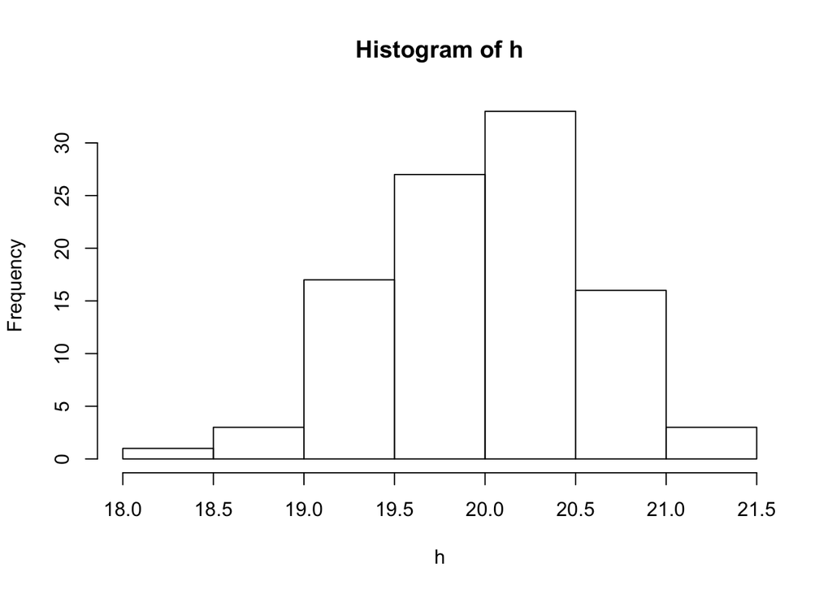

```r
hist(h) #seems super normal to me... lets check with Q-Q
```

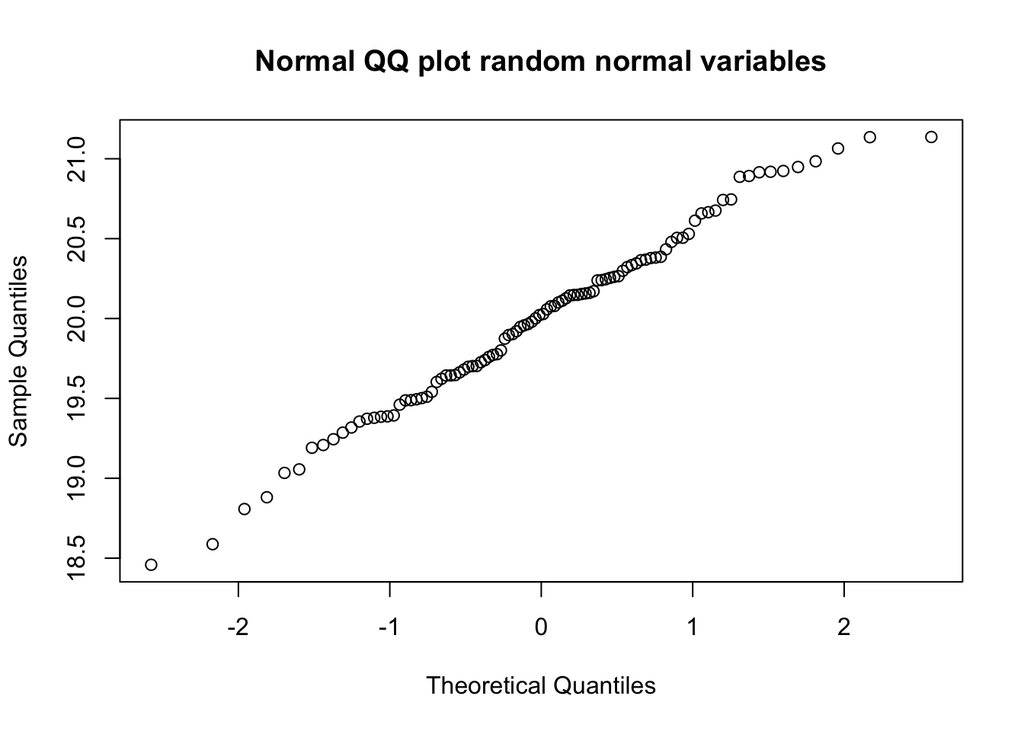

```r
qqnorm(h, main = "Normal QQ plot random normal variables") #yup seems normal
```

# zk

```r
set <- NULL  # sets up a dummy variable to hold our 10000 simulations
n <- 30
for (i in 1:99) {
    set[i] <- mean(sample(d$zombies_killed, n, replace = FALSE))
    }
set
```

```
##  [1] 3.366667 2.333333 2.966667 3.366667 3.133333 3.366667 3.033333
##  [8] 2.833333 3.266667 3.400000 3.100000 3.166667 3.100000 3.300000
## [15] 3.200000 2.866667 2.900000 2.933333 2.733333 3.366667 2.833333
## [22] 3.966667 2.766667 3.100000 2.333333 3.433333 3.033333 3.066667
## [29] 2.933333 2.666667 2.866667 2.766667 3.000000 2.600000 3.200000
## [36] 2.566667 3.033333 3.133333 2.933333 3.133333 3.166667 2.466667
## [43] 2.666667 3.166667 3.200000 2.866667 2.600000 2.766667 2.733333
## [50] 3.200000 3.066667 2.500000 2.766667 2.866667 3.500000 2.733333
## [57] 3.566667 3.200000 3.466667 3.033333 2.933333 2.766667 3.533333
## [64] 3.900000 2.900000 2.933333 3.100000 3.366667 3.000000 3.333333
## [71] 3.433333 2.200000 3.233333 3.400000 3.266667 3.000000 2.900000
## [78] 2.533333 2.900000 3.466667 2.300000 2.966667 2.933333 2.700000
## [85] 2.666667 3.066667 2.866667 3.066667 3.566667 2.666667 2.766667
## [92] 2.900000 3.300000 3.566667 2.766667 3.466667 2.966667 2.833333
## [99] 2.766667
```

```r
mean_of_sample_variables2zk=mean(c(set,mean_of_sample_variables$`mean(zombies_killed)`))
mean_of_sample_variables2zk
```

```
## [1] 3.015667
```

```r
sd_of_sample_variables2zk=sd(c(set, sd_of_sample_variables$`sd(zombies_killed)`))
sd_of_sample_variables2zk
```

```
## [1] 0.3598604
```

```r
#distributions of all 100
set
```

```
##  [1] 3.366667 2.333333 2.966667 3.366667 3.133333 3.366667 3.033333
##  [8] 2.833333 3.266667 3.400000 3.100000 3.166667 3.100000 3.300000
## [15] 3.200000 2.866667 2.900000 2.933333 2.733333 3.366667 2.833333
## [22] 3.966667 2.766667 3.100000 2.333333 3.433333 3.033333 3.066667
## [29] 2.933333 2.666667 2.866667 2.766667 3.000000 2.600000 3.200000
## [36] 2.566667 3.033333 3.133333 2.933333 3.133333 3.166667 2.466667
## [43] 2.666667 3.166667 3.200000 2.866667 2.600000 2.766667 2.733333
## [50] 3.200000 3.066667 2.500000 2.766667 2.866667 3.500000 2.733333
## [57] 3.566667 3.200000 3.466667 3.033333 2.933333 2.766667 3.533333
## [64] 3.900000 2.900000 2.933333 3.100000 3.366667 3.000000 3.333333
## [71] 3.433333 2.200000 3.233333 3.400000 3.266667 3.000000 2.900000
## [78] 2.533333 2.900000 3.466667 2.300000 2.966667 2.933333 2.700000
## [85] 2.666667 3.066667 2.866667 3.066667 3.566667 2.666667 2.766667
## [92] 2.900000 3.300000 3.566667 2.766667 3.466667 2.966667 2.833333
## [99] 2.766667
```

```r
h=c(set,mean_of_sample_variables$`mean(zombies_killed)`)
h
```

```
##   [1] 3.366667 2.333333 2.966667 3.366667 3.133333 3.366667 3.033333
##   [8] 2.833333 3.266667 3.400000 3.100000 3.166667 3.100000 3.300000
##  [15] 3.200000 2.866667 2.900000 2.933333 2.733333 3.366667 2.833333
##  [22] 3.966667 2.766667 3.100000 2.333333 3.433333 3.033333 3.066667
##  [29] 2.933333 2.666667 2.866667 2.766667 3.000000 2.600000 3.200000
##  [36] 2.566667 3.033333 3.133333 2.933333 3.133333 3.166667 2.466667
##  [43] 2.666667 3.166667 3.200000 2.866667 2.600000 2.766667 2.733333
##  [50] 3.200000 3.066667 2.500000 2.766667 2.866667 3.500000 2.733333
##  [57] 3.566667 3.200000 3.466667 3.033333 2.933333 2.766667 3.533333
##  [64] 3.900000 2.900000 2.933333 3.100000 3.366667 3.000000 3.333333
##  [71] 3.433333 2.200000 3.233333 3.400000 3.266667 3.000000 2.900000
##  [78] 2.533333 2.900000 3.466667 2.300000 2.966667 2.933333 2.700000
##  [85] 2.666667 3.066667 2.866667 3.066667 3.566667 2.666667 2.766667
##  [92] 2.900000 3.300000 3.566667 2.766667 3.466667 2.966667 2.833333
##  [99] 2.766667 2.700000
```

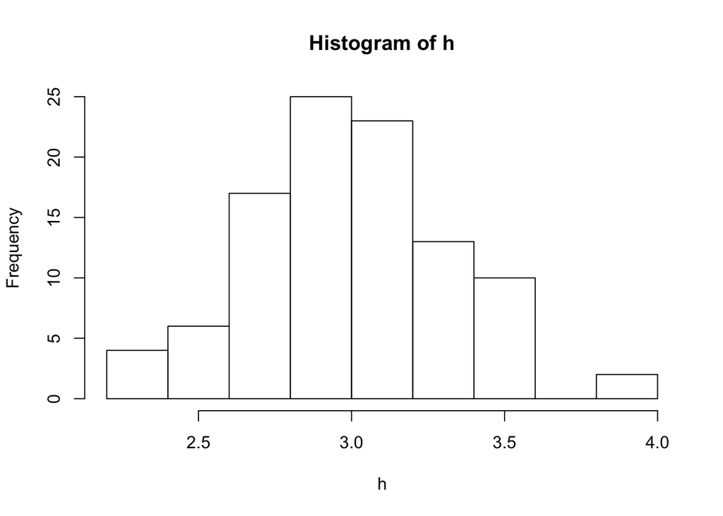

```r
hist(h) #seems super normal to me... lets check with Q-Q
```

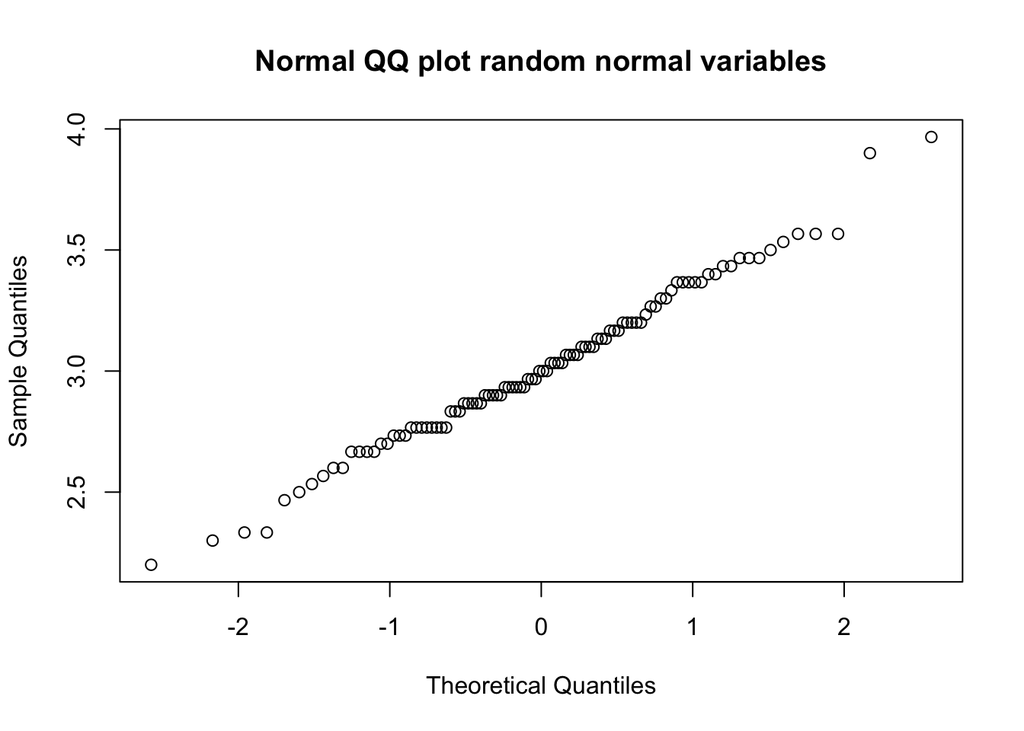

```r
qqnorm(h, main = "Normal QQ plot random normal variables") #yup seems normal
```

# yoe

```r
set <- NULL  # sets up a dummy variable to hold our 10000 simulations
n <- 30
for (i in 1:99) {
    set[i] <- mean(sample(d$years_of_education, n, replace = FALSE))
    }
set
```

```
##  [1] 2.633333 3.266667 3.033333 3.000000 2.833333 2.933333 2.866667
##  [8] 2.900000 3.133333 2.900000 2.800000 2.733333 2.933333 2.466667
## [15] 2.866667 3.333333 2.533333 2.900000 2.533333 3.266667 2.700000
## [22] 3.100000 2.633333 3.566667 3.366667 3.500000 3.466667 4.266667
## [29] 2.766667 3.133333 2.666667 2.566667 3.066667 2.800000 3.200000
## [36] 3.066667 3.033333 3.500000 2.366667 2.800000 3.166667 2.733333
## [43] 2.700000 2.800000 3.200000 3.266667 3.000000 3.000000 2.766667
## [50] 2.833333 2.633333 2.700000 2.633333 2.900000 3.033333 2.933333
## [57] 2.766667 3.066667 2.433333 2.400000 3.033333 2.800000 3.300000
## [64] 2.766667 2.966667 3.166667 2.866667 3.266667 2.500000 2.566667
## [71] 2.866667 3.533333 2.666667 2.600000 3.333333 2.800000 3.033333
## [78] 2.800000 3.066667 2.633333 2.800000 3.066667 2.833333 3.266667
## [85] 2.800000 2.933333 2.966667 2.533333 2.800000 3.200000 3.033333
## [92] 2.700000 3.066667 3.300000 2.900000 2.466667 3.600000 2.900000
## [99] 2.633333
```

```r
mean_of_sample_variables2yoe=mean(c(set,mean_of_sample_variables$`mean(years_of_education)`))
mean_of_sample_variables2yoe
```

```
## [1] 2.937667
```

```r
sd_of_sample_variables2yoe=sd(c(set, sd_of_sample_variables$`sd(years_of_education)`))
sd_of_sample_variables2yoe
```

```
## [1] 0.3271073
```

```r
#distributions of all 100
set
```

```
##  [1] 2.633333 3.266667 3.033333 3.000000 2.833333 2.933333 2.866667
##  [8] 2.900000 3.133333 2.900000 2.800000 2.733333 2.933333 2.466667
## [15] 2.866667 3.333333 2.533333 2.900000 2.533333 3.266667 2.700000
## [22] 3.100000 2.633333 3.566667 3.366667 3.500000 3.466667 4.266667
## [29] 2.766667 3.133333 2.666667 2.566667 3.066667 2.800000 3.200000
## [36] 3.066667 3.033333 3.500000 2.366667 2.800000 3.166667 2.733333
## [43] 2.700000 2.800000 3.200000 3.266667 3.000000 3.000000 2.766667
## [50] 2.833333 2.633333 2.700000 2.633333 2.900000 3.033333 2.933333
## [57] 2.766667 3.066667 2.433333 2.400000 3.033333 2.800000 3.300000
## [64] 2.766667 2.966667 3.166667 2.866667 3.266667 2.500000 2.566667
## [71] 2.866667 3.533333 2.666667 2.600000 3.333333 2.800000 3.033333
## [78] 2.800000 3.066667 2.633333 2.800000 3.066667 2.833333 3.266667
## [85] 2.800000 2.933333 2.966667 2.533333 2.800000 3.200000 3.033333
## [92] 2.700000 3.066667 3.300000 2.900000 2.466667 3.600000 2.900000
## [99] 2.633333
```

```r
h=c(set,mean_of_sample_variables$`mean(years_of_education)`)
h
```

```
##   [1] 2.633333 3.266667 3.033333 3.000000 2.833333 2.933333 2.866667
##   [8] 2.900000 3.133333 2.900000 2.800000 2.733333 2.933333 2.466667
##  [15] 2.866667 3.333333 2.533333 2.900000 2.533333 3.266667 2.700000
##  [22] 3.100000 2.633333 3.566667 3.366667 3.500000 3.466667 4.266667
##  [29] 2.766667 3.133333 2.666667 2.566667 3.066667 2.800000 3.200000
##  [36] 3.066667 3.033333 3.500000 2.366667 2.800000 3.166667 2.733333
##  [43] 2.700000 2.800000 3.200000 3.266667 3.000000 3.000000 2.766667
##  [50] 2.833333 2.633333 2.700000 2.633333 2.900000 3.033333 2.933333
##  [57] 2.766667 3.066667 2.433333 2.400000 3.033333 2.800000 3.300000
##  [64] 2.766667 2.966667 3.166667 2.866667 3.266667 2.500000 2.566667
##  [71] 2.866667 3.533333 2.666667 2.600000 3.333333 2.800000 3.033333
##  [78] 2.800000 3.066667 2.633333 2.800000 3.066667 2.833333 3.266667
##  [85] 2.800000 2.933333 2.966667 2.533333 2.800000 3.200000 3.033333
##  [92] 2.700000 3.066667 3.300000 2.900000 2.466667 3.600000 2.900000
##  [99] 2.633333 3.000000
```

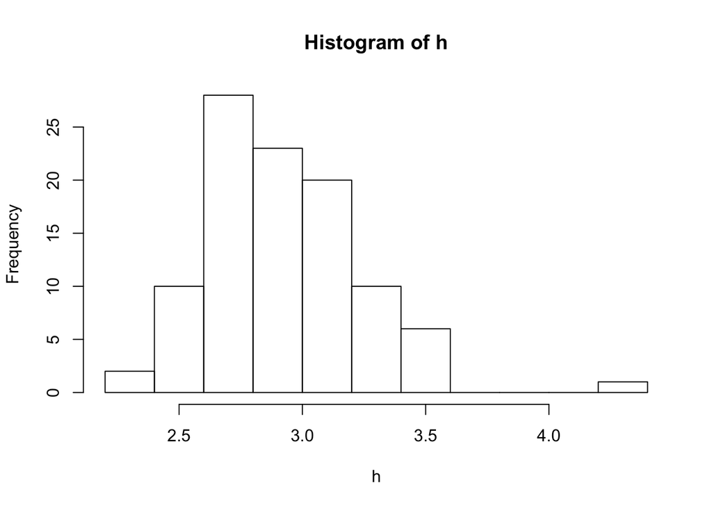

```r
hist(h) #seems super normal to me... lets check with Q-Q
```

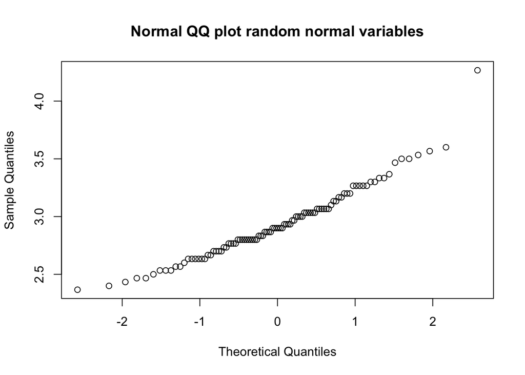

```r
qqnorm(h, main = "Normal QQ plot random normal variables") #yup seems normal
```

# sd #6 > SE#5 but the sd#6 < sd#5

# the zk and yoe are now more normal becasue we bootstrapped them